# ChIP-seq Analysis of TGF-beta Treated SMAD2 and SMAD3 Peaks

# 1 Introduction

Smad2 and Smad3 are both DNA-binding proteins that are activated by TGFβ signalling, and have differing downstream targets and phenotypic effects. The predominance of either the Smad2 or the Smad3 pathway over the other can determine the overall effect of signalling TGFβ . The aim of this analysis was to determine the difference between the Smad2 and the Smad3 axes of the TGFβ pathway, by looking at already-called ChIP-seq peaks for Smad2 and Smad3, and comparing the functional significance of their corresponding genes by looking at associated Gene Ontology terms.

# 2 Methods and Code

This section contains details of the analysis method and the code used to implement the analysis.

## 2.1 Libraries

The following libraries were loaded during this analysis:

1. tidyverse
2. formatR
3. GenomicRanges
4. org.Hs.eg.db
5. TxDb.Hsapiens.UCSC.hg38.knownGene
6. ChIPseeker
7. clusterProfiler
8. kableExtra

## 2.2 Annotating Peaks

Peaks were annotated using the **ChIPseeker** package. The annotated peaks for each of the conditions were further filtered into three subsets:

1. All peaks
2. Peaks with only promoter annotations.
3. Peaks lying within genic regions, i.e., peaks without the annotations “Distal Intergenic” and “Downstream”

The following code was used to read in the file names and create a character vector from them. Those names were then fed into a function to convert those files into Granges objects held in a list.

```r
knitr::opts_chunk$set(echo = FALSE, tidy = TRUE)

## Takes a filename as string input, and if it has suffix '.narrowPeak', converts it to a GRanges
## object containing a q_value metadata column. Requires tidyverse and GRanges packages.

## checking for existence of file and correct extension
narrow_to_granges <- function(file) {
    stopifnot(file.exists(file), endsWith(x = file, suffix = ".narrowPeak"))


    bed <- as_tibble(read_tsv(file = file, col_names = c("chrom", "start", "end", "name", "score", "strand",
        "signal_value", "p_value", "q_value", "peak")))


    gr <- GRanges(seqnames = bed$chrom, ranges = IRanges(start = bed$start, end = bed$end), strand = if_else(condition = bed$strand ==
        "+" | bed$strand == "-", true = bed$strand, false = "*"), q_value = bed$q_value)

    return(gr)
}


### To read in multiple .narrowPeak files and create a GRanges list of GRanges objects with the input of
### respective files.

files <- dir(path = ".", pattern = "\\.narrowPeak$")  ## specify files in character vector

grl <- lapply(files, narrow_to_granges)  ## Create list of GRanges object
```

Here are the contents of the files vector.

```r
files
```

```
[1] "SMAD2_abInput_treated_peaks.narrowPeak"   "SMAD2_abInput_untreated_peaks.narrowPeak"
[3] "SMAD3_LAP_treated_peaks.narrowPeak"       "SMAD3_LAP_untreated_peaks.narrowPeak"
```

The following code was then used to assign the Granges in the list to separate variables. The name of the variable to hold each GRange object was derived from the respective file name from which its data was obtained. The names of the variables were stored as a character vector “v”.To names in v, the respective GRange was assigned.

```r
TxDb <- TxDb.Hsapiens.UCSC.hg38.knownGene

## vector of variable names for granges in list

v <- str_remove_all(string = files, pattern = "\\.narrowPeak$")

### Assign individual granges within grl to variable names in v.

for (i in seq_along(grl)) {
    assign(x = v[i], value = grl[[i]])
}
```

Here are the names of the variables held in vector v:

```r
v
```

```
[1] "SMAD2_abInput_treated_peaks"   "SMAD2_abInput_untreated_peaks"
[3] "SMAD3_LAP_treated_peaks"       "SMAD3_LAP_untreated_peaks"
```

A character vector of variable names was created to hold the annotated peak objects derived from the GRanges.

```r
ap_v <- paste0("AP_", v)  ## variable names for annotated peak objects

ap_v
### Create annotated peak objects and assign them to names in ap_v
```

```r
for (i in seq_along(grl)) {
    assign(x = ap_v[i], value = annotatePeak(peak = grl[[i]], TxDb = TxDb, annoDb = "org.Hs.eg.db"))
}
```

[output not shown]

[output not shown]

[output not shown]

[output not shown]

```
>> assigning chromosome lengths          2021-01-07 22:15:17
>> done...                   2021-01-07 22:15:17
```

```r
AP_SMAD2_abInput_treated_peaks
```

```
Annotated peaks generated by ChIPseeker
4822/4822  peaks were annotated
Genomic Annotation Summary:
```

|  | Feature | Frequency |
| --- | --- | --- |
| 9 | Promoter (<=1kb) | 6.51182082 |
| 10 | Promoter (1-2kb) | 2.48859394 |
| 11 | Promoter (2-3kb) | 1.86644546 |
| 4 | 5' UTR | 0.08295313 |
| 3 | 3' UTR | 0.43550394 |
| 1 | 1st Exon | 1.90792202 |
| 7 | Other Exon | 1.01617586 |
| 2 | 1st Intron | 6.67772708 |
| 8 | Other Intron | 13.74948154 |
| 6 | Downstream (<=300) | 0.41476566 |

[output cut: 1 more lines]

```r
df_ap_v <- paste0("df_", ap_v)  ## variable names for tibbles derived from annotated peaks

df_ap_v
```

```r
### Create tibbles from annotated peak objects listed in ap_v and assign them to names in df_ap_v

for (i in seq_along(ap_v)) {
    assign(x = df_ap_v[i], value = parse(text = ap_v[i]) %>% eval() %>% AnnotationDbi::as.data.frame() %>%
        as_tibble())
}
```

```r
df_AP_SMAD2_abInput_treated_peaks
```

| seqnames | start | end | width | strand | q_value | annotation | geneChr | geneStart | geneEnd | geneLength | geneStrand | geneId | transcriptId | distanceToTSS | ENSEMBL | SYMBOL | GENENAME |
| --- | --- | --- | --- | --- | --- | --- | --- | --- | --- | --- | --- | --- | --- | --- | --- | --- | --- |
| chr1 | 200115 | 200225 | 111 | * | 4.49881 | Distal Intergenic | 1 | 187891 | 187958 | 68 | 2 | 102466751 | ENST00000612080.1 | -12157 | ENSG00000278267 | MIR6859-1 | microRNA 6859-1 |
| chr1 | 598094 | 598166 | 73 | * | 3.83276 | Exon (ENST00000357876.6/ENST00000357876.6, exon 1 of 2) | 1 | 627377 | 631150 | 3774 | 2 | 101928626 | ENST00000452176.2 | 32984 | ENSG00000230021 | LOC101928626 | uncharacterized LOC101928626 |
| chr1 | 598318 | 598371 | 54 | * | 3.87465 | Exon (ENST00000357876.6/ENST00000357876.6, exon 1 of 2) | 1 | 627377 | 631150 | 3774 | 2 | 101928626 | ENST00000452176.2 | 32779 | ENSG00000230021 | LOC101928626 | uncharacterized LOC101928626 |
| chr1 | 598570 | 598691 | 122 | * | 4.64770 | Intron (ENST00000634833.2/ENST00000634833.2, intron 3 of 5) | 1 | 627377 | 631150 | 3774 | 2 | 101928626 | ENST00000452176.2 | 32459 | ENSG00000230021 | LOC101928626 | uncharacterized LOC101928626 |
| chr1 | 629303 | 629353 | 51 | * | 3.71157 | Promoter (1-2kb) | 1 | 627377 | 631150 | 3774 | 2 | 101928626 | ENST00000452176.2 | 1797 | ENSG00000230021 | LOC101928626 | uncharacterized LOC101928626 |
| chr1 | 629433 | 629639 | 207 | * | 12.45950 | Promoter (1-2kb) | 1 | 627377 | 631150 | 3774 | 2 | 101928626 | ENST00000452176.2 | 1511 | ENSG00000230021 | LOC101928626 | uncharacterized LOC101928626 |
| chr1 | 629714 | 629774 | 61 | * | 5.81809 | Promoter (1-2kb) | 1 | 627377 | 631150 | 3774 | 2 | 101928626 | ENST00000452176.2 | 1376 | ENSG00000230021 | LOC101928626 | uncharacterized LOC101928626 |
| chr1 | 629890 | 629948 | 59 | * | 5.67877 | Promoter (1-2kb) | 1 | 627377 | 631150 | 3774 | 2 | 101928626 | ENST00000452176.2 | 1202 | ENSG00000230021 | LOC101928626 | uncharacterized LOC101928626 |
| chr1 | 630177 | 630236 | 60 | * | 3.58487 | Promoter (<=1kb) | 1 | 627377 | 631150 | 3774 | 2 | 101928626 | ENST00000452176.2 | 914 | ENSG00000230021 | LOC101928626 | uncharacterized LOC101928626 |
| chr1 | 630468 | 630577 | 110 | * | 3.90626 | Promoter (<=1kb) | 1 | 627377 | 631150 | 3774 | 2 | 101928626 | ENST00000452176.2 | 573 | ENSG00000230021 | LOC101928626 | uncharacterized LOC101928626 |

[output cut: 990 more lines]

```r
NA
```

```r
## variable names for tibbles derived from annotated peaks limited to promoter annotations

prom_df_ap_v <- paste0("prom_df_", ap_v)
prom_df_ap_v
```

```
[1] "prom_df_AP_SMAD2_abInput_treated_peaks"   "prom_df_AP_SMAD2_abInput_untreated_peaks"
[3] "prom_df_AP_SMAD3_LAP_treated_peaks"       "prom_df_AP_SMAD3_LAP_untreated_peaks"
```

```r
### Create subset of tibbles from variable names listed in df_ap_v and assign them to variable names in
### prom_df_ap_v
for (i in seq_along(df_ap_v)) {
    assign(x = prom_df_ap_v[i], value = parse(text = df_ap_v[i]) %>% eval() %>% filter(str_detect(annotation,
        "Promoter")))
}

prom_df_AP_SMAD2_abInput_treated_peaks
```

```r
## variable names for tibbles derived from annotated peaks limited to gene region annotations

gen_df_ap_v <- paste0("gen_df_", ap_v)

gen_df_ap_v
```

```r
### Filter tibbles with variable names listed in df_ap_v to discard rows with 'Distal Intergenic' or
### 'Downstream' annotations and assign them to names in gen_df_ap_v.

for (i in seq_along(df_ap_v)) {
    assign(x = gen_df_ap_v[i], value = parse(text = df_ap_v[i]) %>% eval() %>% filter(!str_detect(annotation,
        "Distal Intergenic|Downstream")))
}
```

```r
gen_df_AP_SMAD3_LAP_treated_peaks
```

## 2.3 GO Term Enrichment Analysis of Annotated Peaks

GO term enrichment analysis of the annotated peaks was carried out using the **ClusterProfiler** package. Analysis was carried out for all four conditions and each subset of annotated peaks within each condition (all peaks, promoter-limited peaks and genic region-limited peaks).

**Note:** The following code takes *very* long to run.

### 2.3.1 GO term enrichment for all peaks

```r
ego_v <- paste0("ego_", v)  ### Vector of variable names for go term enrichment objects


for (i in seq_along(ego_v)) {
    ego <- parse(text = df_ap_v[i]) %>% eval(expr = .) %>% dplyr::select(geneId) %>% unlist() %>% enrichGO(gene = .,
        OrgDb = org.Hs.eg.db, ont = "BP", pAdjustMethod = "BH", readable = TRUE)
    if (!nrow(as.data.frame(ego)) == 0)
        assign(x = ego_v[i], value = ego)
}
```

```r
ego_SMAD2_abInput_treated_peaks
```

```
#
# over-representation test
#
#...@organism    Homo sapiens
#...@ontology    BP
#...@keytype     ENTREZID
#...@gene    chr [1:1920] "102466751" "101928626" "100133331" "643837" "388581" "9651" "79258" ...
#...pvalues adjusted by 'BH' with cutoff <0.05
#...31 enriched terms found
'data.frame':   31 obs. of  9 variables:
 $ ID         : chr  "GO:0007409" "GO:0007411" "GO:0097485" "GO:0048638" ...
 $ Description: chr  "axonogenesis" "axon guidance" "neuron projection guidance" "regulation of developmental growth" ...
 $ GeneRatio  : chr  "75/1280" "52/1280" "52/1280" "47/1280" ...
 $ BgRatio    : chr  "468/18670" "276/18670" "277/18670" "347/18670" ...
 $ pvalue     : num  3.92e-12 2.07e-11 2.38e-11 5.86e-06 9.19e-06 ...
 $ p.adjust   : num  2.17e-08 4.39e-08 4.39e-08 8.09e-03 1.01e-02 ...
 $ qvalue     : num  2.00e-08 4.05e-08 4.05e-08 7.48e-03 9.38e-03 ...
 $ geneID     : chr  "MACF1/DOCK7/TNR/LGR6/ENAH/ANK3/EGR2/SEMA4G/BRSK2/MARK2/CTTN/PAK1/GAB2/NTN4/ATP8A2/SLITRK1/SIPA1L1/PSEN1/EVL/SEM"| __truncated__ "TNR/LGR6/ENAH/EGR2/SEMA4G/GAB2/NTN4/EVL/SEMA6D/MAPK3/GRB2/PTPRM/RNF165/DCC/DOK6/SPTBN4/SOS1/NRXN1/SEMA4F/KIF5C/"| __truncated__ "TNR/LGR6/ENAH/EGR2/S…
 $ Count      : int  75 52 52 47 44 21 41 51 34 33 ...
#...Citation
  Guangchuang Yu, Li-Gen Wang, Yanyan Han and Qing-Yu He.
  clusterProfiler: an R package for comparing biological themes among
  gene clusters. OMICS: A Journal of Integrative Biology
  2012, 16(5):284-287
```

### 2.3.2 GO term enrichment for promoter-proximal peaks

```r
### Vector of variable names for go term enrichment objects limited to promoter peaks

prom_ego_v <- ego_v <- paste0("prom_ego_", v)

prom_ego_v
```

```
[1] "prom_ego_SMAD2_abInput_treated_peaks"   "prom_ego_SMAD2_abInput_untreated_peaks"
[3] "prom_ego_SMAD3_LAP_treated_peaks"       "prom_ego_SMAD3_LAP_untreated_peaks"
```

```r
### Performing go term analysis using the clusterprofiler package and assigning the results to the
### variables in gen_ego_v

for (i in seq_along(prom_ego_v)) {
    ego <- parse(text = prom_df_ap_v[i]) %>% eval(expr = .) %>% dplyr::select(geneId) %>% unlist() %>%
        enrichGO(gene = ., OrgDb = org.Hs.eg.db, ont = "BP", pAdjustMethod = "BH", readable = TRUE)
    if (!nrow(as.data.frame(ego)) == 0)
        assign(x = prom_ego_v[i], value = ego)
}
```

### 2.3.3 GO term enrichment for peaks lying within genic regions

```r
### Vector of variable names for go term enrichment objects limited to genic region peaks

gen_ego_v <- paste0("gen_ego_", v)

gen_ego_v
```

```r
### Performing go term analysis using the clusterprofiler package and assigning the results to the
### variables in gen_ego_v

for (i in seq_along(gen_ego_v)) {
    ego <- parse(text = gen_df_ap_v[i]) %>% eval(expr = .) %>% dplyr::select(geneId) %>% unlist() %>%
        enrichGO(gene = ., OrgDb = org.Hs.eg.db, ont = "BP", pAdjustMethod = "BH", readable = TRUE)
    if (!nrow(as.data.frame(ego)) == 0)
        assign(x = gen_ego_v[i], value = ego)
}


rm(ego)  ## removing unnecessary variable ego
```

# 3 Results

## 3.1 Peak annotation results

### 3.1.1 SMAD2 peaks - untreated

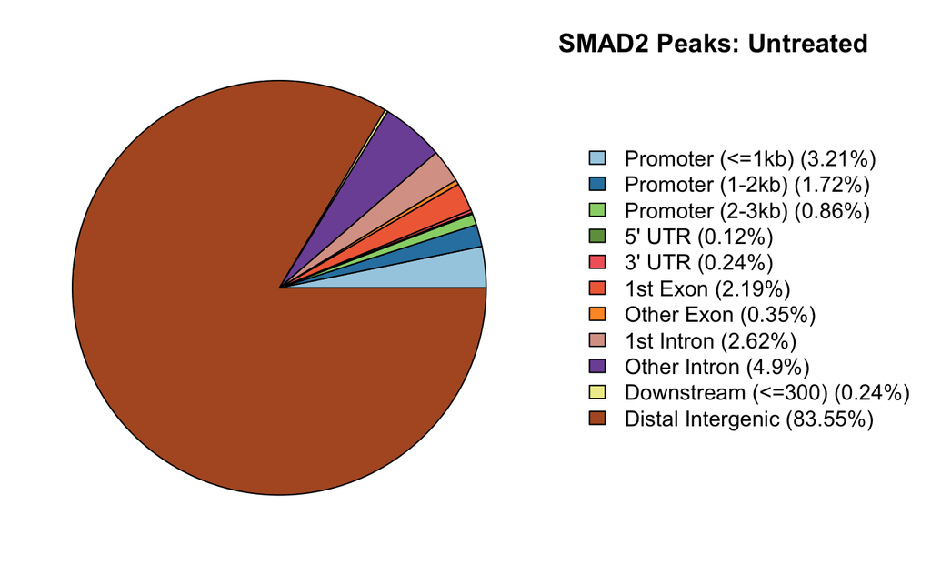

### 3.1.2 SMAD2 peaks - treated

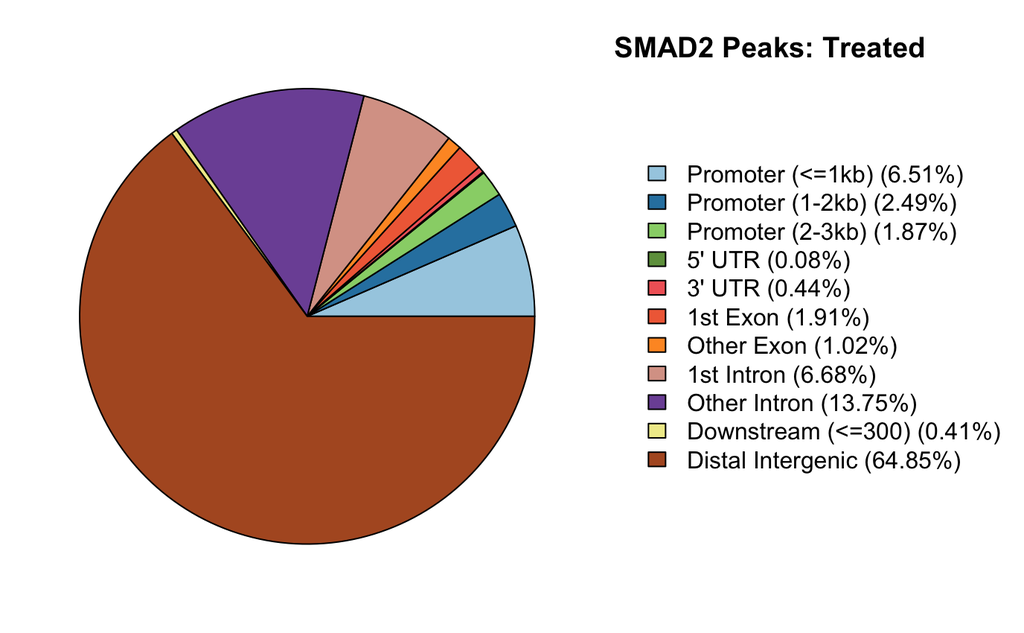

### 3.1.3 SMAD3 peaks - untreated

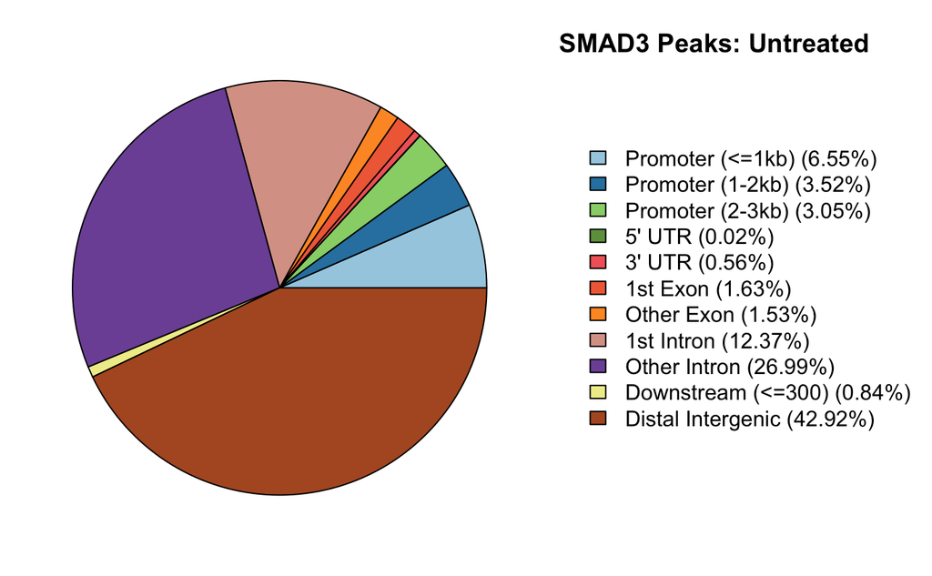

### 3.1.4 SMAD3 peaks - treated

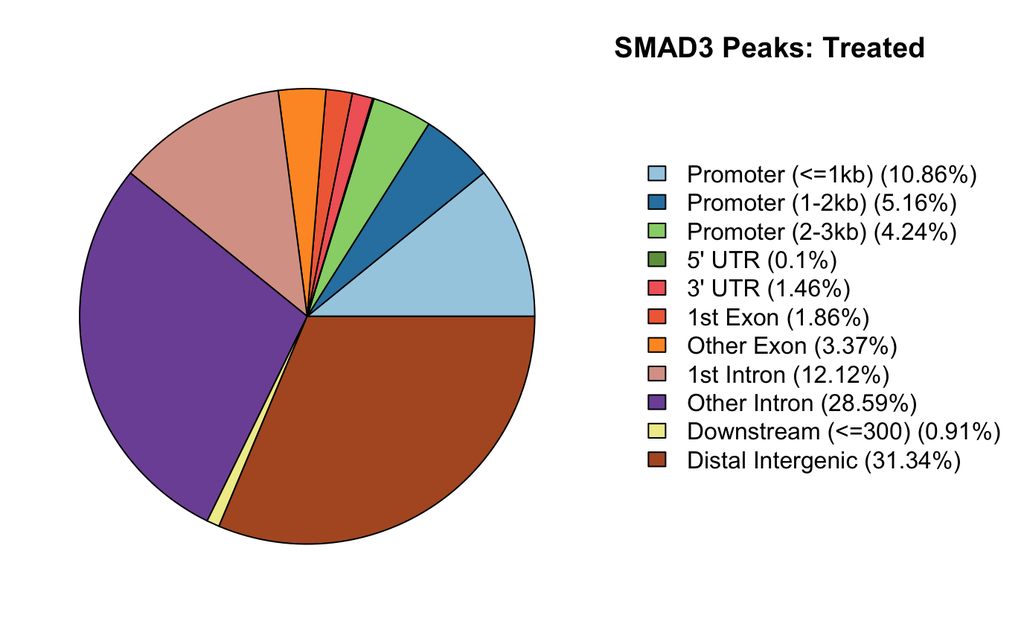

## 3.2 GO term analysis results

GO term analysis was limited to biological process (BP) terms; GO Terms relating to Cellular Component and Molecular Function were not analysed.

### 3.2.1 GO term analysis for all peaks

No enriched BP GO terms were found within annotations for untreated SMAD2 peaks. This may have been due to the majority of these peaks being located in the intergenic regions. For treated SMAD2 peaks, GO terms related to processes in neuronal development were over-represented.

**Note:** Only the first 20 enriched GO terms for each peak subset and condition are shown. Terms were arranged in ascending order by adjusted p value, then in descending order by gene ratio and absolute count.

| Enriched GO Terms in Treated SMAD2 Peaks | p.adjust | GeneRatio | BgRatio |
| --- | --- | --- | --- |
| axonogenesis | 2.167034e-08 | 75/1280 | 468/18670 |
| axon guidance | 4.386623e-08 | 52/1280 | 276/18670 |
| neuron projection guidance | 4.386623e-08 | 52/1280 | 277/18670 |
| regulation of developmental growth | 8.088310e-03 | 47/1280 | 347/18670 |
| peptidyl-serine modification | 1.014860e-02 | 44/1280 | 322/18670 |
| smooth muscle contraction | 1.474959e-02 | 21/1280 | 110/18670 |
| regulation of cell morphogenesis involved in differentiation | 1.560137e-02 | 41/1280 | 301/18670 |
| synapse organization | 1.587625e-02 | 51/1280 | 408/18670 |
| developmental cell growth | 1.603754e-02 | 34/1280 | 234/18670 |
| peptidyl-serine phosphorylation | 1.734020e-02 | 40/1280 | 299/18670 |

[output cut: 10 more lines]

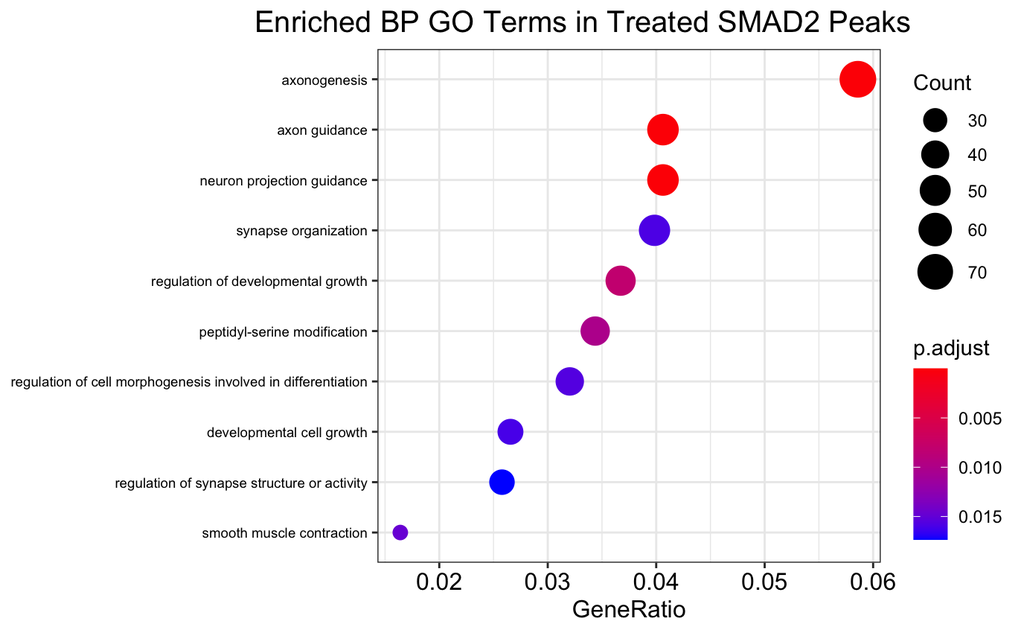

Untreated SMAD3 peaks also showed an enrichment in neuronal development-related terms. In addition, peaks in regions related to GTPase activity and cell-cell adhesion were also enriched.

| Enriched GO Terms in Untreated SMAD3 Peaks | p.adjust | GeneRatio | BgRatio |
| --- | --- | --- | --- |
| axonogenesis | 7.967845e-11 | 156/3481 | 468/18670 |
| synapse organization | 3.909655e-10 | 138/3481 | 408/18670 |
| cell-cell adhesion via plasma-membrane adhesion molecules | 1.131522e-09 | 101/3481 | 273/18670 |
| synapse assembly | 1.131522e-09 | 74/3481 | 177/18670 |
| regulation of GTPase activity | 4.211998e-07 | 145/3481 | 479/18670 |
| forebrain development | 7.501133e-07 | 120/3481 | 381/18670 |
| neuron migration | 7.501133e-07 | 62/3481 | 157/18670 |
| neuron projection guidance | 1.478956e-06 | 93/3481 | 277/18670 |
| positive regulation of GTPase activity | 2.095859e-06 | 124/3481 | 405/18670 |
| axon guidance | 2.174113e-06 | 92/3481 | 276/18670 |

[output cut: 10 more lines]

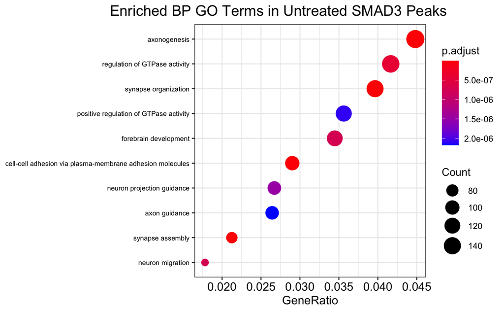

Similar terms related to neuronal development also appeared in treated SMAD3 peaks. However, additional enriched terms such as “regulation of small GTPase-mediated signal transduction”, as well as “regulation of Ras protein signal transduction” were also found to be enriched.

| Enriched GO Terms in Treated SMAD3 Peaks | p.adjust | GeneRatio | BgRatio |
| --- | --- | --- | --- |
| axonogenesis | 6.787262e-16 | 303/8249 | 468/18670 |
| synapse organization | 1.757360e-12 | 260/8249 | 408/18670 |
| regulation of small GTPase mediated signal transduction | 1.757360e-12 | 222/8249 | 338/18670 |
| regulation of GTPase activity | 4.728534e-11 | 293/8249 | 479/18670 |
| regulation of Ras protein signal transduction | 8.429235e-11 | 162/8249 | 238/18670 |
| positive regulation of GTPase activity | 6.040788e-10 | 250/8249 | 405/18670 |
| neuron projection guidance | 1.684486e-09 | 180/8249 | 277/18670 |
| axon guidance | 1.948176e-09 | 179/8249 | 276/18670 |
| synapse assembly | 1.948176e-09 | 124/8249 | 177/18670 |
| developmental growth involved in morphogenesis | 2.841799e-09 | 156/8249 | 235/18670 |

[output cut: 10 more lines]

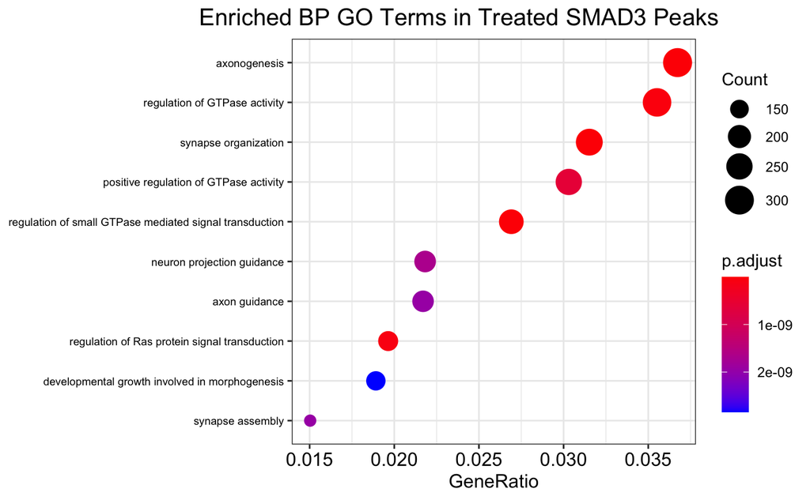

### 3.2.2 GO Term Analysis for Peaks Restricted to Gene Regions

| Enriched GO Terms in Treated SMAD2 Peaks Restricted to Gene Regions | p.adjust | GeneRatio | BgRatio |
| --- | --- | --- | --- |
| axonogenesis | 2.289031e-05 | 53/889 | 468/18670 |
| axon guidance | 2.401937e-05 | 37/889 | 276/18670 |
| neuron projection guidance | 2.401937e-05 | 37/889 | 277/18670 |
| synapse organization | 7.089321e-03 | 41/889 | 408/18670 |
| regulation of developmental growth | 2.208848e-02 | 35/889 | 347/18670 |
| regulation of signaling receptor activity | 2.208848e-02 | 22/889 | 173/18670 |
| synapse assembly | 2.702388e-02 | 22/889 | 177/18670 |
| regulation of cell morphogenesis involved in differentiation | 3.029158e-02 | 31/889 | 301/18670 |
| peptidyl-serine modification | 3.333582e-02 | 32/889 | 322/18670 |
| regulation of axonogenesis | 3.333582e-02 | 22/889 | 183/18670 |

[output cut: 2 more lines]

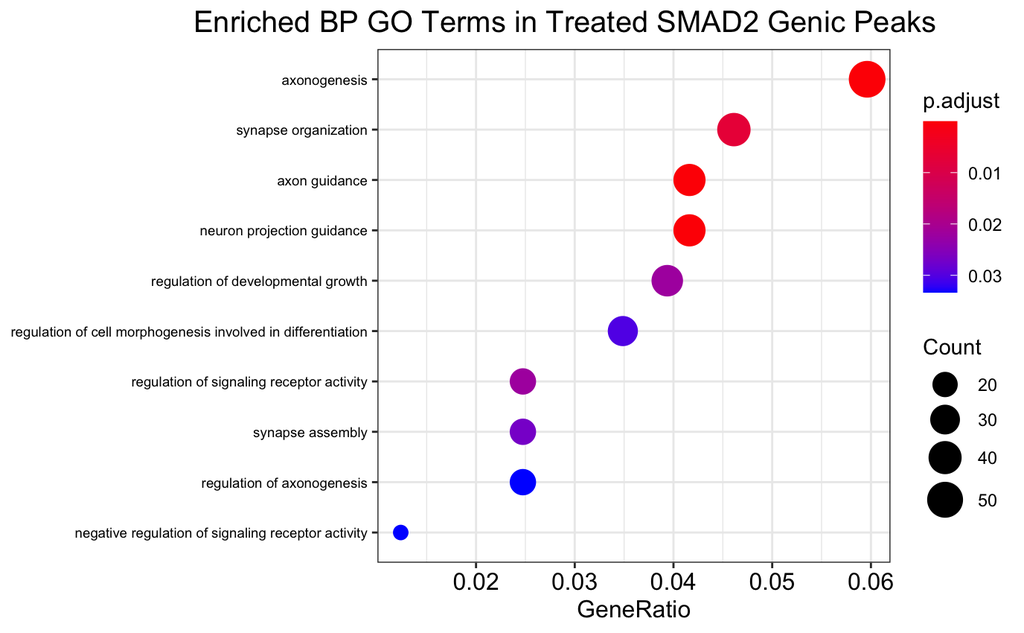

Untreated SMAD3 peaks in gene regions showed a similar neuronal development theme for the most significantly enriched genes.

| Enriched GO Terms in Untreated SMAD3 Peaks Restricted to Gene Regions | p.adjust | GeneRatio | BgRatio |
| --- | --- | --- | --- |
| axonogenesis | 9.948137e-12 | 124/2423 | 468/18670 |
| cell-cell adhesion via plasma-membrane adhesion molecules | 1.636641e-08 | 78/2423 | 273/18670 |
| synapse organization | 1.109861e-07 | 101/2423 | 408/18670 |
| neuron projection guidance | 1.296482e-07 | 76/2423 | 277/18670 |
| axon guidance | 2.247391e-07 | 75/2423 | 276/18670 |
| regulation of GTPase activity | 4.449361e-07 | 111/2423 | 479/18670 |
| synapse assembly | 6.352995e-07 | 54/2423 | 177/18670 |
| regulation of neuron projection development | 1.978615e-06 | 112/2423 | 499/18670 |
| modulation of chemical synaptic transmission | 3.865993e-06 | 100/2423 | 436/18670 |
| regulation of trans-synaptic signaling | 3.947910e-06 | 100/2423 | 437/18670 |

[output cut: 10 more lines]

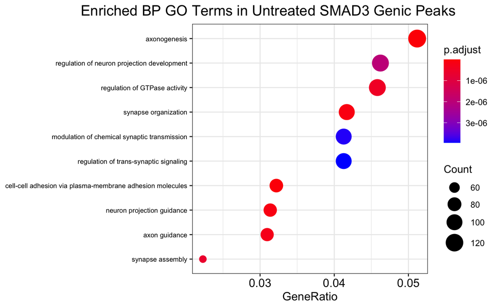

Treated SMAD3 peaks in gene regions did not show too many chages either, as compared to the the set of all treated SMAD3 peaks.

| Enriched GO Terms in Treated SMAD3 Peaks Restricted to Gene Regions | p.adjust | GeneRatio | BgRatio |
| --- | --- | --- | --- |
| axonogenesis | 2.926051e-14 | 259/6717 | 468/18670 |
| regulation of GTPase activity | 7.087595e-14 | 262/6717 | 479/18670 |
| synapse organization | 1.168366e-12 | 226/6717 | 408/18670 |
| positive regulation of GTPase activity | 7.415098e-12 | 222/6717 | 405/18670 |
| positive regulation of cell projection organization | 2.717293e-10 | 207/6717 | 383/18670 |
| regulation of small GTPase mediated signal transduction | 2.717293e-10 | 187/6717 | 338/18670 |
| positive regulation of neuron differentiation | 3.800981e-10 | 201/6717 | 371/18670 |
| neuron projection guidance | 5.490256e-09 | 155/6717 | 277/18670 |
| regulation of Ras protein signal transduction | 5.490256e-09 | 137/6717 | 238/18670 |
| axon guidance | 7.385040e-09 | 154/6717 | 276/18670 |

[output cut: 10 more lines]

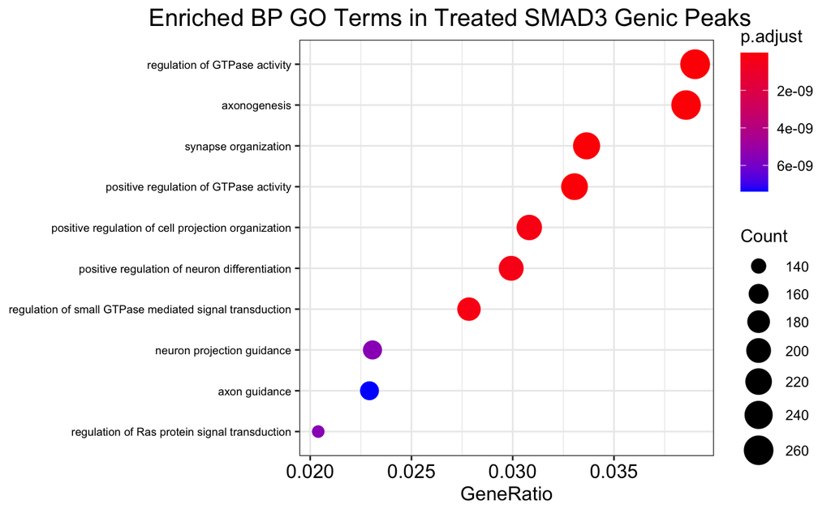

### 3.2.3 GO Term Analysis for Peaks Restricted to Promoter Regions

When peaks were limited to promoter regions, the enriched GO term sets showed noticeable differences from sets derived from all peaks as well as sets derived from peaks limited to gene regions. No enriched GO terms were found for treated promoter-proximal SMAD2 peaks.

| Enriched GO Terms in Untreated SMAD2 Peaks Restricted to Promoters | p.adjust | GeneRatio | BgRatio |
| --- | --- | --- | --- |
| negative regulation of execution phase of apoptosis | 2.654143e-06 | 5/45 | 24/18670 |
| regulation of execution phase of apoptosis | 2.269772e-05 | 5/45 | 41/18670 |
| negative regulation of signaling receptor activity | 8.216273e-05 | 5/45 | 57/18670 |
| execution phase of apoptosis | 5.454870e-04 | 5/45 | 88/18670 |
| regulation of signaling receptor activity | 1.165883e-02 | 5/45 | 173/18670 |
| pyrimidine nucleotide biosynthetic process | 3.075841e-02 | 3/45 | 46/18670 |
| signal transduction in response to DNA damage | 3.682003e-02 | 4/45 | 133/18670 |
| pyrimidine-containing compound biosynthetic process | 3.682003e-02 | 3/45 | 56/18670 |
| blood vessel endothelial cell differentiation | 3.682003e-02 | 2/45 | 11/18670 |
| pyrimidine nucleotide metabolic process | 4.068917e-02 | 3/45 | 62/18670 |

[output cut: 2 more lines]

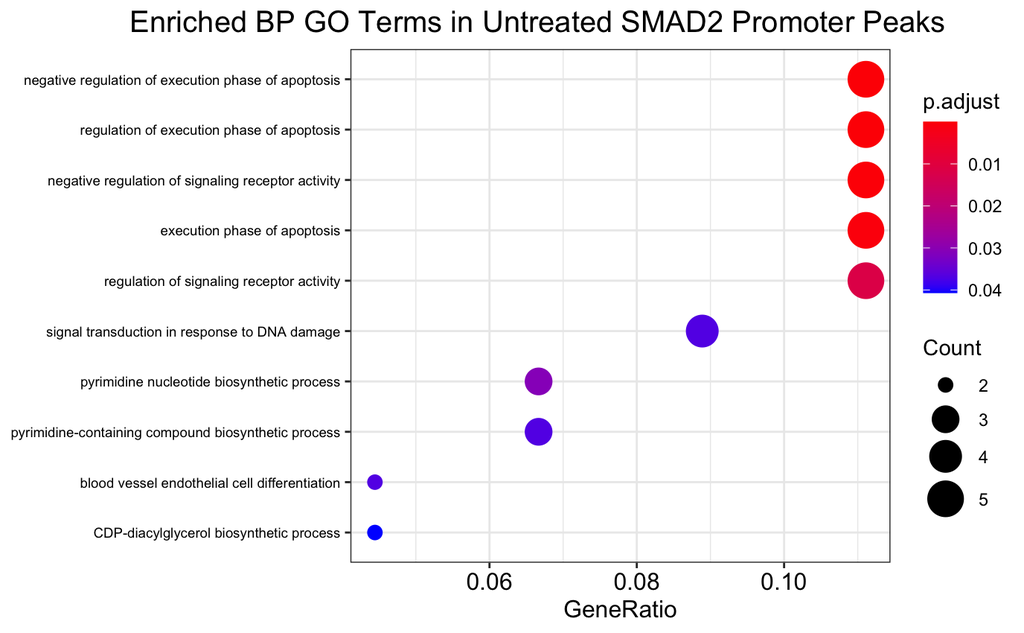

Untreated SMAD3 peaks restricted to promoters showed the least number of enriched terms, all of which were related to cell-cell adhesion.

| Enriched GO Terms in Untreated SMAD3 Peaks Restricted to Promoters | p.adjust | GeneRatio | BgRatio |
| --- | --- | --- | --- |
| homophilic cell adhesion via plasma membrane adhesion molecules | 1.208727e-08 | 29/680 | 168/18670 |
| cell-cell adhesion via plasma-membrane adhesion molecules | 4.947179e-05 | 31/680 | 273/18670 |
| calcium-dependent cell-cell adhesion via plasma membrane cell adhesion molecules | 1.567723e-04 | 12/680 | 48/18670 |

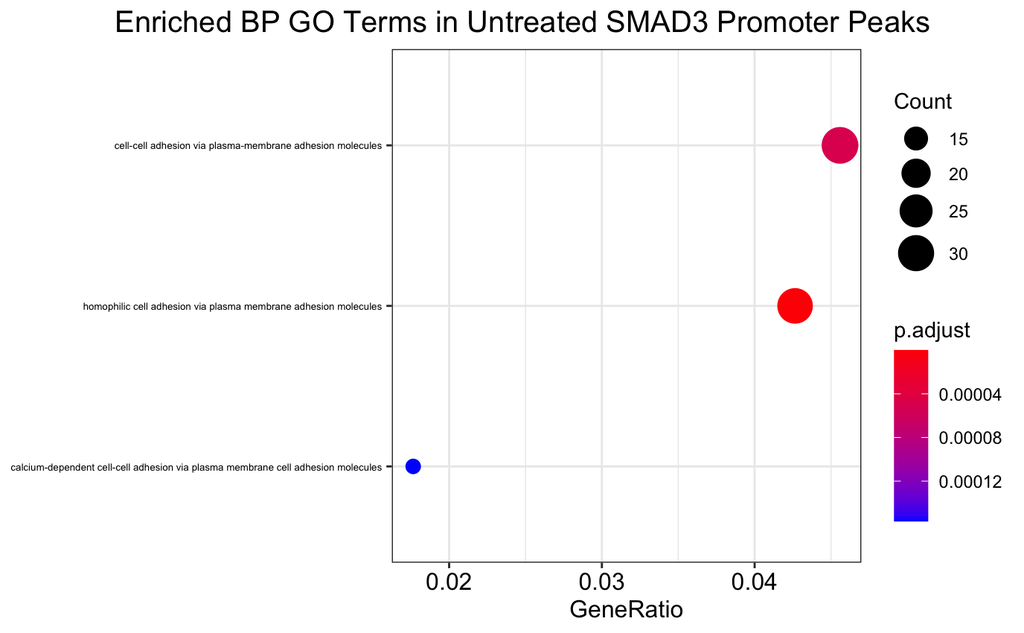

Treatment with ligand seemed to show many more enriched GO terms in promoter-restricted SMAD3 peaks, as compared to untreated promoter-restricted SMAD3 peaks.

| Enriched GO Terms in Treated SMAD3 Peaks Restricted to Promoters | p.adjust | GeneRatio | BgRatio |
| --- | --- | --- | --- |
| regulation of small GTPase mediated signal transduction | 6.481774e-06 | 100/3117 | 338/18670 |
| regulation of Ras protein signal transduction | 6.481774e-06 | 77/3117 | 238/18670 |
| regulation of GTPase activity | 1.573606e-05 | 129/3117 | 479/18670 |
| positive regulation of GTPase activity | 2.435546e-05 | 112/3117 | 405/18670 |
| regulation of Rho protein signal transduction | 4.896631e-05 | 50/3117 | 140/18670 |
| epithelial tube morphogenesis | 3.033460e-03 | 86/3117 | 322/18670 |
| Rho protein signal transduction | 3.033460e-03 | 60/3117 | 203/18670 |
| activation of GTPase activity | 6.979303e-03 | 34/3117 | 97/18670 |
| endosomal transport | 8.049125e-03 | 63/3117 | 224/18670 |
| neural tube closure | 1.838758e-02 | 31/3117 | 90/18670 |

[output cut: 10 more lines]

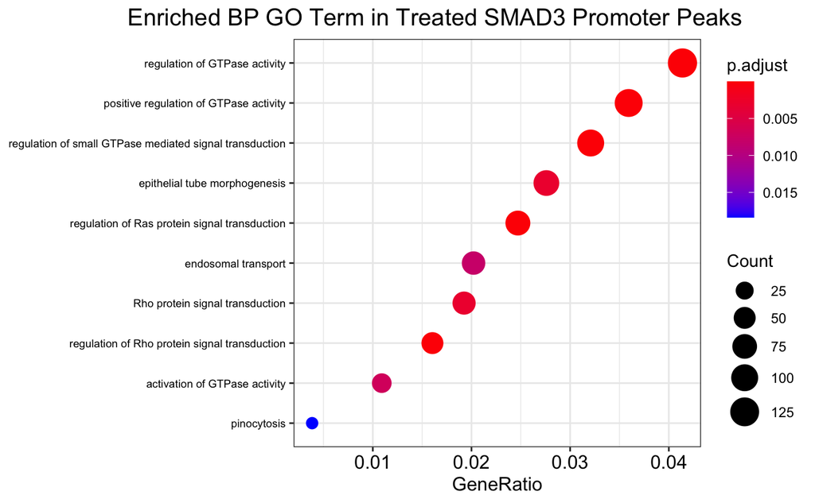